# SoS Workflow Report

| Command Line | `sos run Process_Oriented.sos -p Process_Oriented_Report.html -d` |
| --- | --- |
| Project directory | `/home/gaow/Documents/GIT/wiki/sos-docs/src/examples` |
| Worklow Name | `default` |
| Worklow ID | `d107c1ed414121b3` |
| Worklow Start Time | 2018-06-13 20:08:13 (1528938493.7977116) |
| Worklow End Time | 2018-06-13 20:08:55 |
| Worklow Duration | 41 sec |
| Completed steps | 7 |
| Ignored steps | 1 |
| Completed substeps | 27 |
| Ignored substeps | 5 |

## Steps

Workflow

Step

Input

Output

Start Time

Duration

Timeline

Steps

Substeps

Tasks

default

2018-06-13 20:08:13

41 sec

7 completed 1 ignored

27 completed 5 ignored

default_1

2018-06-13 20:08:15

39 sec

1 completed

1 completed

default_2

data_1.lasso.mse.csv (10)

- data_1.lasso.mse.csv 28 Bytes
- data_1.ridge.mse.csv 33 Bytes
- data_2.lasso.mse.csv 28 Bytes
- data_2.ridge.mse.csv 33 Bytes
- data_3.lasso.mse.csv 28 Bytes
- data_3.ridge.mse.csv 33 Bytes
- data_4.lasso.mse.csv 27 Bytes
- data_4.ridge.mse.csv 35 Bytes
- data_5.lasso.mse.csv 28 Bytes
- data_5.ridge.mse.csv 34 Bytes

2018-06-13 20:08:55

0 sec

1 completed

1 completed

ridge

2018-06-13 20:08:16

27 sec

3 completed

15 completed

ridge_1

data_1.train.csv (10)

- data_1.train.csv 6.5 kB
- data_1.test.csv 32.6 kB
- data_2.train.csv 6.5 kB
- data_2.test.csv 32.5 kB
- data_3.train.csv 6.5 kB
- data_3.test.csv 32.6 kB
- data_4.train.csv 6.6 kB
- data_4.test.csv 32.6 kB
- data_5.train.csv 6.5 kB
- data_5.test.csv 32.6 kB

2018-06-13 20:08:20

3 sec

1 completed

5 completed

ridge_2

data_1.train.csv (10)

- data_1.train.csv 6.5 kB
- data_1.test.csv 32.6 kB
- data_2.train.csv 6.5 kB
- data_2.test.csv 32.5 kB
- data_3.train.csv 6.5 kB
- data_3.test.csv 32.6 kB
- data_4.train.csv 6.6 kB
- data_4.test.csv 32.6 kB
- data_5.train.csv 6.5 kB
- data_5.test.csv 32.6 kB

data_1.ridge.pred... (10)

- data_1.ridge.predicted.csv 3.5 kB
- data_1.ridge.coef.csv 143 Bytes
- data_2.ridge.predicted.csv 3.5 kB
- data_2.ridge.coef.csv 145 Bytes
- data_3.ridge.predicted.csv 3.5 kB
- data_3.ridge.coef.csv 145 Bytes
- data_4.ridge.predicted.csv 3.5 kB
- data_4.ridge.coef.csv 142 Bytes
- data_5.ridge.predicted.csv 3.5 kB
- data_5.ridge.coef.csv 145 Bytes

2018-06-13 20:08:23

16 sec

1 completed

5 completed

ridge_3

data_1.ridge.pred... (10)

- data_1.ridge.predicted.csv 3.5 kB
- data_1.ridge.coef.csv 143 Bytes
- data_2.ridge.predicted.csv 3.5 kB
- data_2.ridge.coef.csv 145 Bytes
- data_3.ridge.predicted.csv 3.5 kB
- data_3.ridge.coef.csv 145 Bytes
- data_4.ridge.predicted.csv 3.5 kB
- data_4.ridge.coef.csv 142 Bytes
- data_5.ridge.predicted.csv 3.5 kB
- data_5.ridge.coef.csv 145 Bytes

data_1.ridge.mse.csv (5)

- data_1.ridge.mse.csv 33 Bytes
- data_2.ridge.mse.csv 33 Bytes
- data_3.ridge.mse.csv 33 Bytes
- data_4.ridge.mse.csv 35 Bytes
- data_5.ridge.mse.csv 34 Bytes

2018-06-13 20:08:40

3 sec

1 completed

5 completed

lasso

2018-06-13 20:08:44

10 sec

2 completed 1 ignored

10 completed 5 ignored

lasso_1

data_1.train.csv (10)

- data_1.train.csv 6.5 kB
- data_1.test.csv 32.6 kB
- data_2.train.csv 6.5 kB
- data_2.test.csv 32.5 kB
- data_3.train.csv 6.5 kB
- data_3.test.csv 32.6 kB
- data_4.train.csv 6.6 kB
- data_4.test.csv 32.6 kB
- data_5.train.csv 6.5 kB
- data_5.test.csv 32.6 kB

2018-06-13 20:08:44

1 sec

1 ignored

5 ignored

lasso_2

data_1.train.csv (10)

- data_1.train.csv 6.5 kB
- data_1.test.csv 32.6 kB
- data_2.train.csv 6.5 kB
- data_2.test.csv 32.5 kB
- data_3.train.csv 6.5 kB
- data_3.test.csv 32.6 kB
- data_4.train.csv 6.6 kB
- data_4.test.csv 32.6 kB
- data_5.train.csv 6.5 kB
- data_5.test.csv 32.6 kB

data_1.lasso.pred... (10)

- data_1.lasso.predicted.csv 5.1 kB
- data_1.lasso.coef.csv 204 Bytes
- data_2.lasso.predicted.csv 5.1 kB
- data_2.lasso.coef.csv 200 Bytes
- data_3.lasso.predicted.csv 5.1 kB
- data_3.lasso.coef.csv 203 Bytes
- data_4.lasso.predicted.csv 5.1 kB
- data_4.lasso.coef.csv 200 Bytes
- data_5.lasso.predicted.csv 5.1 kB
- data_5.lasso.coef.csv 203 Bytes

2018-06-13 20:08:45

6 sec

1 completed

5 completed

lasso_3

data_1.lasso.pred... (10)

- data_1.lasso.predicted.csv 5.1 kB
- data_1.lasso.coef.csv 204 Bytes
- data_2.lasso.predicted.csv 5.1 kB
- data_2.lasso.coef.csv 200 Bytes
- data_3.lasso.predicted.csv 5.1 kB
- data_3.lasso.coef.csv 203 Bytes
- data_4.lasso.predicted.csv 5.1 kB
- data_4.lasso.coef.csv 200 Bytes
- data_5.lasso.predicted.csv 5.1 kB
- data_5.lasso.coef.csv 203 Bytes

data_1.lasso.mse.csv (5)

- data_1.lasso.mse.csv 28 Bytes
- data_2.lasso.mse.csv 28 Bytes
- data_3.lasso.mse.csv 28 Bytes
- data_4.lasso.mse.csv 27 Bytes
- data_5.lasso.mse.csv 28 Bytes

2018-06-13 20:08:51

3 sec

1 completed

5 completed

## Execution DAG

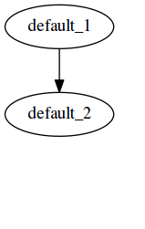

## Script

105 lines 4.4 kB